# WK4 The Fourth Industrial Revolution

[interactive chart not shown]

Industrial Revolution

Graph depicting four Industrial

Revolutions, in progression from the

18th century to the 21st.

© V

ectimus/Shutterstock.com

The Fourth Industrial Revolution

The Fourth Industrial Revolution heralds a series of social, political, cultural, and economic

upheavals that will unfold over the 21st century

. Building on the widespread availability of

digital technologies that were the result of the Third Industrial, or

Digital, Revolution, the

gence of digital, biological,

and physical innovations.

Like the

First Industrial Revolution

’s steam-powered

factories, the

Second Industrial Revolution’

s application

of science to mass production and manufacturing, and

the Third Industrial Revolution’

s start into digitization,

the Fourth Industrial Revolution’

s technologies, such as

artificial intelligence, genome editing, augmented reality

,

robotics, and 3-D printing, are rapidly changing the way

humans create, exchange, and distribute value. As

occurred in the previous revolutions, this will profoundly

transform institutions, industries, and individuals. More

importantly

, this revolution will be guided by the choices that people make today: the world in

50 to 100 years from now will owe a lot of its character to how we think about, invest in, and

deploy these powerful new technologies.

[We all need to become futurist citizens. Julie Friedman Steele explains how

.]

It’s important to appreciate that the Fourth Industrial Revolution involves a systemic change

across many sectors and aspects of human life: the crosscutting impacts of emer

ging

technologies are even more important than the exciting capabilities they represent. Our ability

to

edit the building blocks of life has recently been massively expanded by low-cost gene

sequencing and techniques such as CRISPR;

artificial intelligence is augmenting processes

and skill in every industry;

neurotechnology is making unprecedented strides in how we can

use and influence the brain as the last frontier of human biology;

automation is disrupting

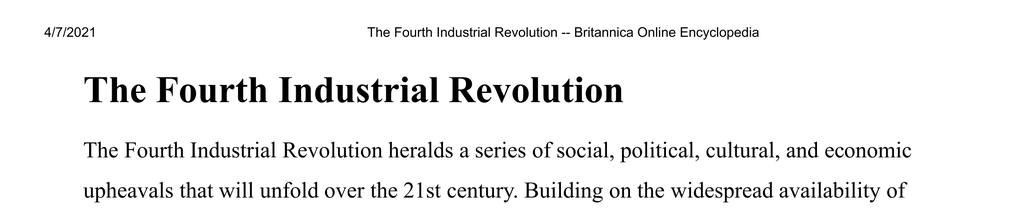

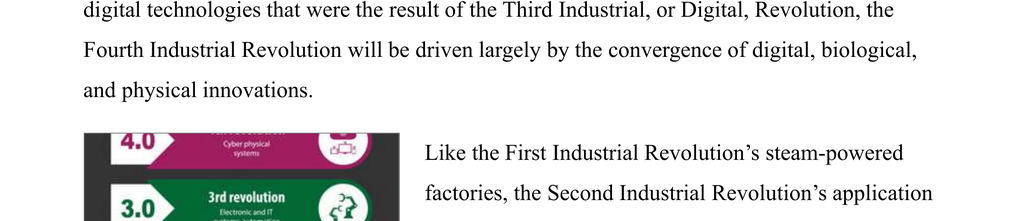

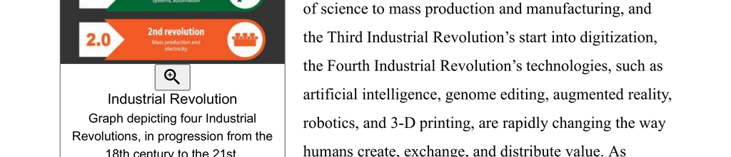

[figure not shown]

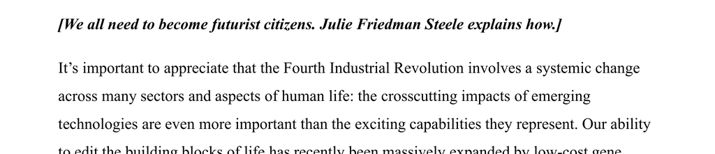

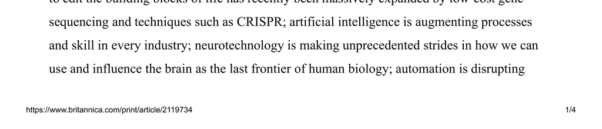

century-old transport and manufacturing paradigms; and technologies such as blockchain and

smart materials are redefining and blurring the boundary between the digital and physical

worlds.

The result of all this is

societal transformation at a global scale. By af

fecting the incentives,

rules, and norms of economic life, it transforms how we communicate, learn, entertain

ourselves, and relate to one another and how we understand ourselves as human beings.

Furthermore, the sense that new technologies are being developed and implemented at an

increasingly rapid pace has an impact on human identities, communities, and political

structures. As a result, our responsibilities to one another

, our opportunities for self-

realization, and our ability to positively impact the world are intricately tied to and shaped by

how we engage with the technologies of the Fourth Industrial Revolution. This revolution is

not just happening to us—we are not its victims—but rather we have the opportunity and even

responsibility to give it structure and purpose.

As economists Erik Brynjolfsson and Andrew McAfee have pointed out, this revolution could

yield greater

inequality

, particularly in its potential to disrupt labor markets. As automation

substitutes for labor across the entire economy

, the net displacement of workers by machines

might exacerbate the gap between returns to capital and returns to labor

. On the other hand, it

is also possible that the displacement of workers by technology will, in aggregate, result in a

net increase in safe and rewarding jobs.

[What happens if 45 percent of all jobs are automated out of existence in the next 20 years?

Peter H. Diamandis has a few ideas.]

All previous industrial revolutions have had both positive and negative impacts on dif

ferent

stakeholders. Nations have become wealthier

, and technologies have helped pull entire

societies out of poverty

, but the inability to fairly distribute the resulting benefits or anticipate

externalities has resulted in global challenges. By recognizing the risks, whether cybersecurity

threats, misinformation on a massive scale through digital media, potential unemployment, or

increasing social and income inequality

, we can take the steps to align common human values

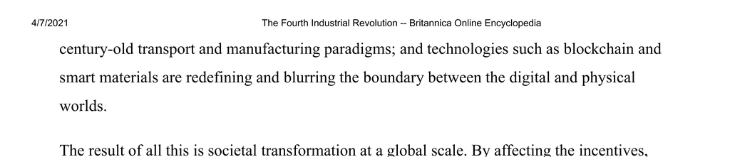

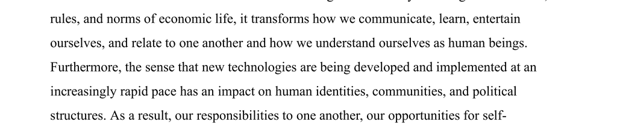

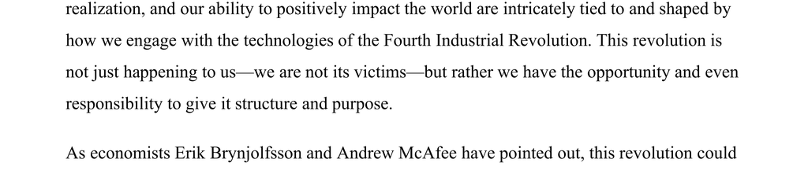

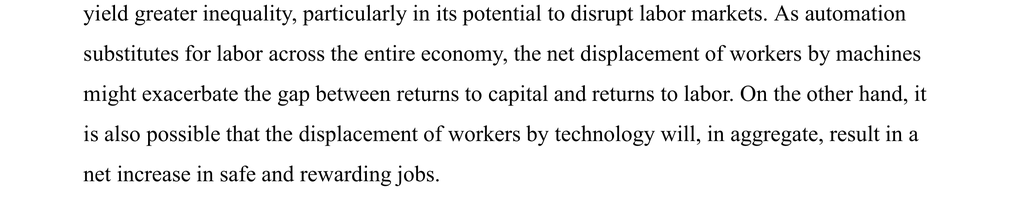

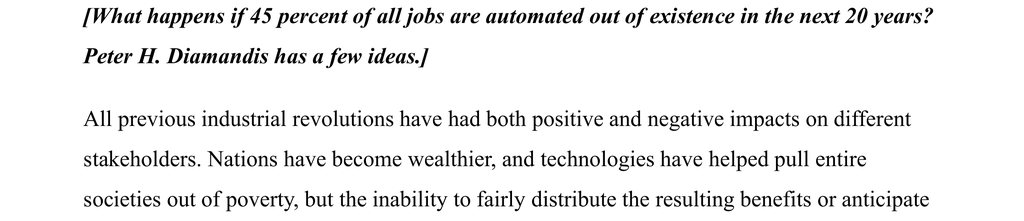

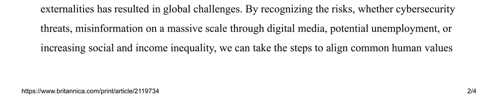

with our technological progress and ensure that the Fourth Industrial Revolution benefits

human beings first and foremost.

We cannot foresee at this point which scenario is likely to emer

ge from this new revolution.

However

, I am convinced of one thing—that in the future, talent, more than capital, will

represent the critical factor of production.

With these fundamental transformations underway today

, we have the opportunity to

proactively shape the Fourth Industrial Revolution to be both inclusive and human-centered.

This revolution is about much more than technology—it is an opportunity to unite global

communities, to build sustainable economies, to adapt and modernize governance models, to

reduce material and social inequalities, and to commit to values-based leadership of emer

ging

technologies.

The Fourth Industrial Revolution is therefore not a prediction of the future but a call to action.

It is a vision for developing, dif

fusing, and governing technologies in ways that foster a more

empowering, collaborative, and sustainable foundation for social and economic development,

built around shared values of the common good, human dignity

, and inter

generational

stewardship. Realizing this vision will be the core challenge and great responsibility of the

next 50 years.

This essay was originally published in 2018 in

Encyclopædia Britannica Anniversary Edition:

250 Years of Excellence (1768–2018).

Klaus Schwab

Citation Information

Article T

itle:

The Fourth Industrial Revolution

Website Name:

Encyclopaedia Britannica

Publisher:

Encyclopaedia Britannica, Inc.

Date Published:

23 March 2021

URL:

https://www

.britannica.com/topic/The-Fourth-Industrial-Revolution-21

19734

Access Date:

April 07, 2021

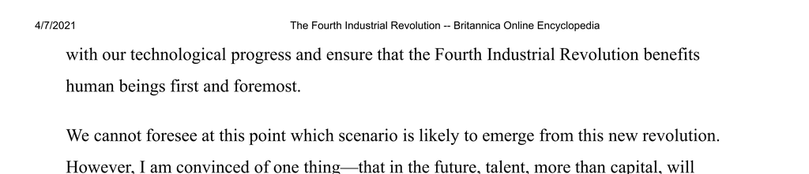

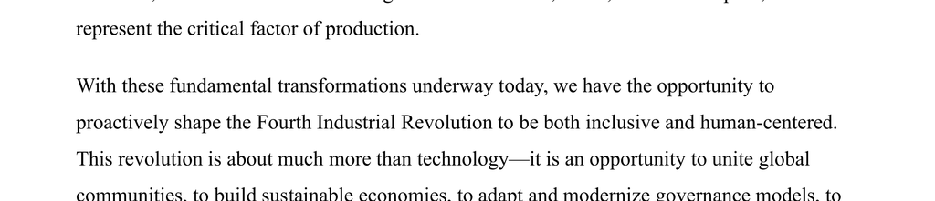

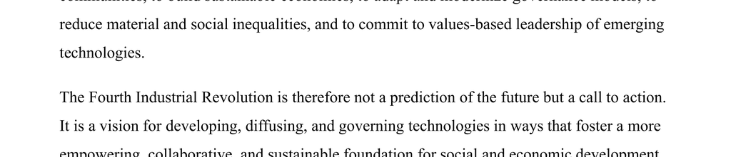

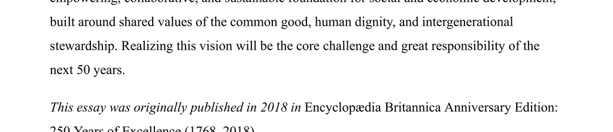

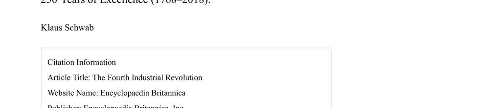

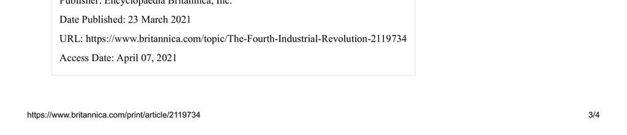

[figure not shown]

[figure not shown]

Shruti Avinash Pawar mentioned you in a comment:

@Sunil Raj Thota As far as I Believe, the naive nature of the disruption that is caused by the fourth revolution seems like a challenge to me. No one is experienced more than one or couple of decade in the AI space and thus everyone is experimenting and gradually learning. In such instance most of the time is spent in doing research and trying out things that are not already done with zero clarity of success or business value.

14 days ago Jian Sun responded to your comment:

Through big data, we get the local foods and entertainment and advertisements immiditely when we arrive to a new place. Moreover, we get advs when we watched videos about it. Goervnment also use big data to find the valuable information and reduces risks and crimes. Business use analysis to make decisions and fin opportunities. The next few years, society need to realize the changes and learn to fit the change.

14 days ago Shanglin Wu responded to your comment:

On the whole, the fourth industrial revolution is sweeping over us in an unprecedented situation. Its development speed, scope, and depth are not inferior to the previous three industrial revolutions. It organically integrates digital technology, physical technology, and biotechnology, and exerts a powerful force that affects our economy and society. At the current stage, major issues such as the transformation of traditional enterprises and the upgrading of manufacturing industries are hot topics. Whether it is a government, an enterprise or an individual, a comprehensive understanding of the connotation and significance of the fourth industrial revolution is bound to be an important weight in the competition for the future world.

14 days ago Rishi Prasana Ravichandran responded to your comment:

Technology has advanced a lot and I strongly feel that meeting these responsibilities is possible with essential collaboration and a sustainable foundation. It is our responsibility to make sure that we take further steps in advancement with keeping the core values in mind. The advancement should not be at the cost of humanity and nature. The advancement should not only focus on raising revenue, but also give way for a sustainable future. It is said that the Fifth Industrial Revolution can be summarised as the combination of humans and machines in the workplace. The positive way of looking at this is to appreciate how AI and robotics significantly alter how we work, play, and live by replacing repetitive and highly complex tasks and assisting us with decision-making.

15 days ago Kajal Amarnani mentioned you in a comment:

I agree @Sunil Raj Thota , with the new transformations, data-centric tools will help leaders manage their teams in an optimal way and provide employees with ample opportunities to grow.

15 days ago Jifei Xie mentioned you in a comment:

Hi,@Sunil Raj Thota. I think Inequality represents the biggest social problem related to the fourth industrial revolution. The biggest beneficiaries of innovation are often the providers of knowledge capital and material capital, which shows that the wealth gap between dependent capital and labor is expanding. = The demand for highly skilled workers has increased while the demand for workers with lower levels of education and skills has decreased. The result is a job market with strong high-end and low-end demand, but there is a hole in the middle.

17 days ago

[figure not shown]

[figure not shown]